# Insurance Claim Prediction Model

**Lead Data Analyst:** Sunday Osagie

**Objective:** Build a predictive model to determine the probability of a building having at least one insurance claim over the insured period based on building characteristics.  
**Target:** 'Claim' (1 = at least one claim, 0 = no claim).

## Importing Libraries

```python
import pandas as pd
import numpy as np
import matplotlib.pyplot as plt
import seaborn as sns
from sklearn.model_selection import train_test_split, GridSearchCV, StratifiedKFold
from sklearn.compose import ColumnTransformer
from sklearn.pipeline import Pipeline
from sklearn.impute import SimpleImputer
from sklearn.preprocessing import StandardScaler, OrdinalEncoder
from sklearn.linear_model import LogisticRegression
from sklearn.ensemble import RandomForestClassifier
from xgboost import XGBClassifier
from sklearn.metrics import classification_report, confusion_matrix, roc_auc_score, precision_recall_curve
from imblearn.pipeline import Pipeline as ImbPipeline
from imblearn.over_sampling import SMOTE
import joblib

%matplotlib inline
sns.set(style='whitegrid')
```

## Loading Datasets

```python
df = pd.read_csv('Train_data.csv')
desc = pd.read_csv('Variable_Description.csv')
print('Data Description:')
print(desc)
print('\nDataset Shape:', df.shape)
df.head()
```

```
Data Description:
              Variable                                        Description
0          Customer Id        Identification number for the Policy holder
1    YearOfObservation         year of observation for the insured policy
2       Insured_Period  duration of insurance policy in Olusola Insura...
3          Residential      is the building a residential building or not
4     Building_Painted  is the building painted or not (N-Painted, V-N...
5      Building_Fenced  is the building fence or not (N-Fenced, V-Not ...
6               Garden  building has garden or not (V-has garden; O-no...
7           Settlement  Area where the building is located. (R- rural ...
8   Building Dimension                 Size of the insured building in m2
9        Building_Type             The type of building (Type 1, 2, 3, 4)
10   Date_of_Occupancy                   date building was first occupied
11     NumberOfWindows                  number of windows in the building
12            Geo Code          Geographical Code of the Insured building
13               Claim  target variable. (0: no claim, 1: at least one...

Dataset Shape: (7160, 14)
```

|  | Customer Id | YearOfObservation | Insured_Period | Residential | Building_Painted | Building_Fenced | Garden | Settlement | Building Dimension | Building_Type | Date_of_Occupancy | NumberOfWindows | Geo_Code | Claim |
| --- | --- | --- | --- | --- | --- | --- | --- | --- | --- | --- | --- | --- | --- | --- |
| 0 | H14663 | 2013 | 1.0 | 0 | N | V | V | U | 290.0 | 1 | 1960.0 | . | 1053 | 0 |
| 1 | H2037 | 2015 | 1.0 | 0 | V | N | O | R | 490.0 | 1 | 1850.0 | 4 | 1053 | 0 |
| 2 | H3802 | 2014 | 1.0 | 0 | N | V | V | U | 595.0 | 1 | 1960.0 | . | 1053 | 0 |
| 3 | H3834 | 2013 | 1.0 | 0 | V | V | V | U | 2840.0 | 1 | 1960.0 | . | 1053 | 0 |
| 4 | H5053 | 2014 | 1.0 | 0 | V | N | O | R | 680.0 | 1 | 1800.0 | 3 | 1053 | 0 |

## Data Cleaning and Preprocessing

```python
# Drop non-predictive IDs
df.drop(['Customer Id', 'Geo_Code'], axis=1, inplace=True, errors='ignore')

# Clean NumberOfWindows
if 'NumberOfWindows' in df.columns:
    df['NumberOfWindows'] = (
        df['NumberOfWindows']
        .astype(str)
        .str.strip()
        .replace({' .': np.nan, '>=10': '10'})
    )
    df['NumberOfWindows'] = pd.to_numeric(df['NumberOfWindows'], errors='coerce')

# Handle Date_of_Occupancy and create Building Age
if 'Date_of_Occupancy' in df.columns:
    # Convert to year
    df['Date_of_Occupancy'] = pd.to_datetime(df['Date_of_Occupancy'], errors='coerce').dt.year

    # Impute missing values
    from sklearn.impute import SimpleImputer
    imputer = SimpleImputer(strategy='median')
    df['Date_of_Occupancy'] = imputer.fit_transform(df[['Date_of_Occupancy']]).astype(int)

    # Calculate Building_Age
    df['Building_Age'] = df['YearOfObservation'] - df['Date_of_Occupancy']
    df['Building_Age'] = df['Building_Age'].clip(lower=0, upper=150)

    # Drop the original column
    df.drop('Date_of_Occupancy', axis=1, inplace=True)

# Rename & clean Building Dimension
if 'Building Dimension' in df.columns:
    df.rename(columns={'Building Dimension': 'Building_Dimension'}, inplace=True)
    df['Building_Dimension'] = imputer.fit_transform(df[['Building_Dimension']])

    # Handle outliers using IQR
    q1 = df['Building_Dimension'].quantile(0.25)
    q3 = df['Building_Dimension'].quantile(0.75)
    iqr = q3 - q1
    df['Building_Dimension'] = df['Building_Dimension'].clip(
        lower=q1 - 1.5*iqr,
        upper=q3 + 1.5*iqr
    )

# Final missing values check
print("\nMissing Values After Cleaning:")
print(df.isna().sum())

# Check numeric and categorical columns
numeric_cols = df.select_dtypes(include=['int64', 'float64']).columns.tolist()
categorical_cols = df.select_dtypes(include=['object']).columns.tolist()

print("\nNumeric Columns:", numeric_cols)
print("Categorical Columns:", categorical_cols)
```

```
Missing Values After Cleaning:
YearOfObservation        0
Insured_Period           0
Residential              0
Building_Painted         0
Building_Fenced          0
Garden                   7
Settlement               0
Building_Dimension       0
Building_Type            0
NumberOfWindows       3551
Claim                    0
Building_Age             0
dtype: int64

Numeric Columns: ['YearOfObservation', 'Insured_Period', 'Residential', 'Building_Dimension', 'Building_Type', 'NumberOfWindows', 'Claim', 'Building_Age']
Categorical Columns: ['Building_Painted', 'Building_Fenced', 'Garden', 'Settlement']
```

## Exploratory Data Analysis (EDA)

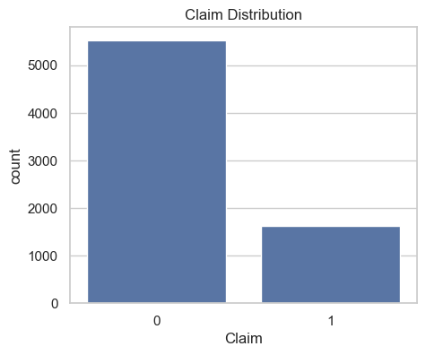

```
Claim Class Distribution (proportion):
Claim
0    0.771788
1    0.228212
Name: proportion, dtype: float64
```

```python
# Target Class Distribution
plt.figure(figsize=(5,4))
sns.countplot(x='Claim', data=df)
plt.title('Claim Distribution')
plt.show()
print("Claim Class Distribution (proportion):")
print(df['Claim'].value_counts(normalize=True))
```

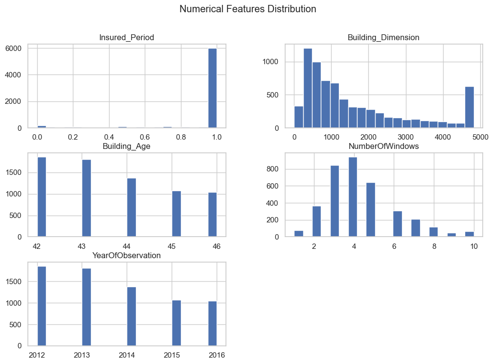

```python
# Numerical Features
num_cols = ['Insured_Period', 'Building_Dimension', 'Building_Age', 'NumberOfWindows', 'YearOfObservation']
df[num_cols].hist(figsize=(12,8), bins=20)
plt.suptitle('Numerical Features Distribution')
plt.show()
```

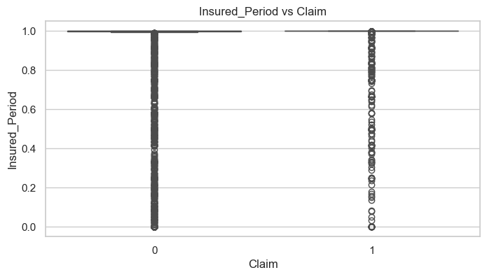

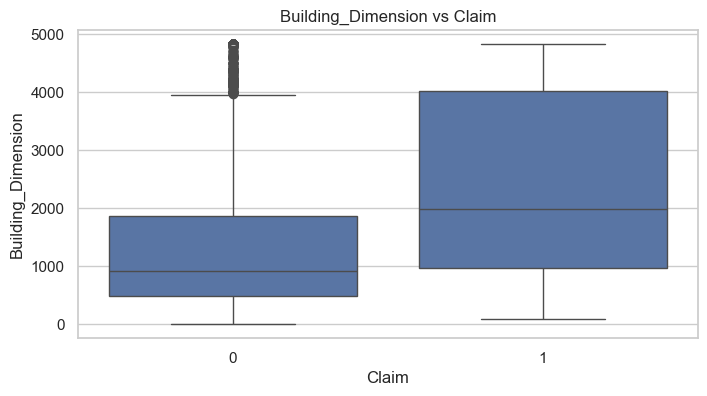

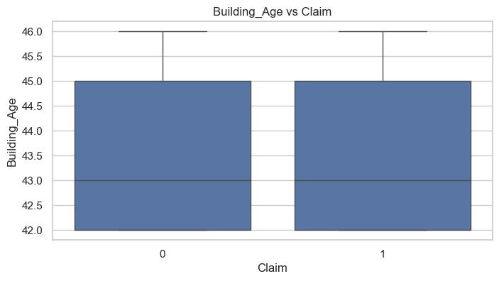

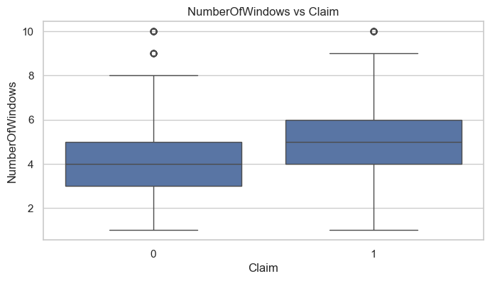

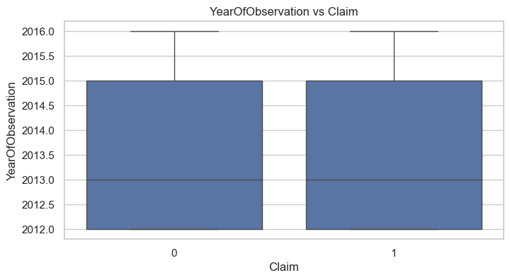

```python
# Boxplots numeric vs Claim
for col in num_cols:
    plt.figure(figsize=(8,4))
    sns.boxplot(x='Claim', y=col, data=df)
    plt.title(f'{col} vs Claim')
    plt.show()
```

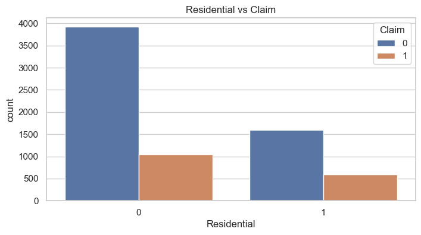

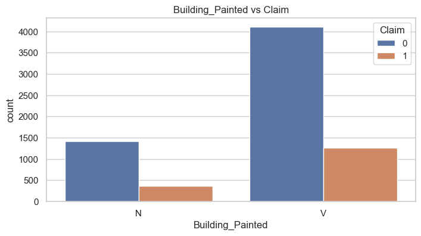

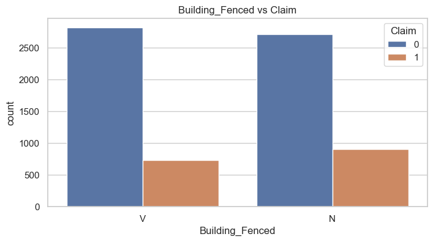

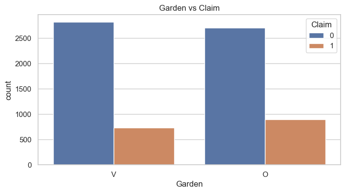

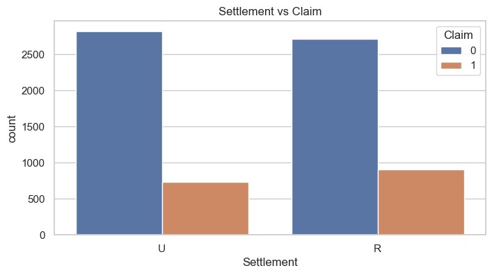

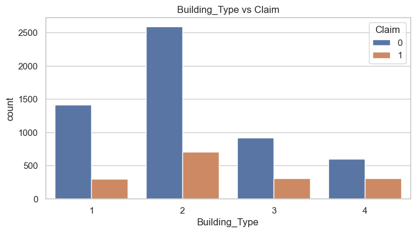

```python
# Categorical vs Claim
cat_cols = ['Residential', 'Building_Painted', 'Building_Fenced', 'Garden', 'Settlement', 'Building_Type']
for col in cat_cols:
    if col in df.columns:
        plt.figure(figsize=(8,4))
        sns.countplot(x=col, hue='Claim', data=df)
        plt.title(f'{col} vs Claim')
        plt.show()
```

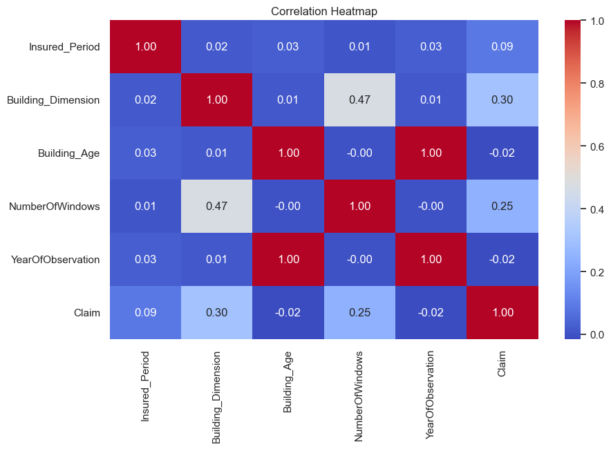

```python
# Correlation Heatmap
plt.figure(figsize=(10,6))
sns.heatmap(df[num_cols + ['Claim']].corr(), annot=True, fmt=".2f", cmap='coolwarm')
plt.title('Correlation Heatmap')
plt.show()
```

## *EDA Key Insights Summary*

- Claims are relatively rare → imbalance confirmed
- Certain building characteristics increase risk
- Feature distributions justify scaling and encoding

## Exploratory Data Analysis (EDA) – Key Insights

- The target variable `Claim` is imbalanced, with fewer buildings experiencing claims.
- This imbalance justifies the use of F1-score and ROC-AUC as primary evaluation metrics.
- Certain building characteristics show higher association with claim occurrence.
- Feature distributions and data types informed the preprocessing steps such as encoding and scaling.

These insights guided the feature preprocessing and model selection stages.

## Data Preprocessing Pipeline and Hyperparameter Tuning

```python
numeric_transformer = Pipeline(steps=[
    ('imputer', SimpleImputer(strategy='median')),
    ('scaler', StandardScaler())
])

categorical_transformer = Pipeline(steps=[
    ('imputer', SimpleImputer(strategy='most_frequent')),
    ('encoder', OrdinalEncoder(handle_unknown='use_encoded_value', unknown_value=-1))
])

preprocessor = ColumnTransformer(
    transformers=[
        ('num', numeric_transformer, num_cols),
        ('cat', categorical_transformer, cat_cols)
    ]
)
```

## Train–Test Split Strategy

To evaluate how well the model generalizes to unseen data, the dataset is split into training and testing sets.

- **Training set**: Used to train the machine learning models.
- **Testing set**: Used strictly for evaluating model performance.

A **stratified split** is applied to preserve the original distribution of the target variable (`Claim`) in both sets, which is critical due to class imbalance.

This approach ensures fair evaluation and reduces the risk of biased performance metrics.

```python
# Train-Test Split
from sklearn.model_selection import train_test_split

X = df.drop('Claim', axis=1)
y = df['Claim']
X_train, X_test, y_train, y_test = train_test_split(
    X, y, test_size=0.2, stratify=y, random_state=42
)
```

## Modeling & Evaluation

```python
def train_evaluate(model, name, X_train, y_train, X_test, y_test, preprocessor):
    pipeline = ImbPipeline(steps=[
        ('preprocessor', preprocessor),
        ('smote', SMOTE(random_state=42)),
        ('classifier', model)
    ])

    param_grid = {}
    if name == 'Logistic Regression':
        param_grid = {
            'classifier__C':[0.1,1,10],
            'classifier__solver':['liblinear'],
            'classifier__max_iter':[500]
        }
    elif name == 'Random Forest':
        param_grid = {
            'classifier__n_estimators':[50,100],
            'classifier__max_depth':[10,20]
        }
    elif name == 'XGBoost':
        param_grid = {
            'classifier__n_estimators':[100,200],
            'classifier__max_depth':[3,5,7],
            'classifier__learning_rate':[0.01,0.1]
        }

    cv = StratifiedKFold(n_splits=5, shuffle=True, random_state=42)
    grid = GridSearchCV(
        estimator=pipeline, param_grid=param_grid, cv=cv, scoring='f1', n_jobs=-1, verbose=1
    )
    grid.fit(X_train, y_train)

    y_pred = grid.predict(X_test)
    y_prob = grid.predict_proba(X_test)[:,1] if hasattr(grid.best_estimator_, 'predict_proba') else None

    print(f"\nBest Params for {name}: {grid.best_params_}")
    print(f"\nClassification Report for {name}:\n{classification_report(y_test, y_pred)}")

    if y_prob is not None:
        roc = roc_auc_score(y_test, y_prob)
        print(f'ROC-AUC for {name}: {roc:.4f}')

        # Precision-Recall Curve
        precision, recall, _ = precision_recall_curve(y_test, y_prob)
        plt.figure(figsize=(8,6))
        plt.plot(recall, precision, marker='.')
        plt.title(f'Precision-Recall Curve for {name}')
        plt.xlabel('Recall')
        plt.ylabel('Precision')
        plt.show()
    else:
        roc = None

    # Confusion Matrix
    cm = confusion_matrix(y_test, y_pred)
    plt.figure(figsize=(6,4))
    sns.heatmap(cm, annot=True, fmt='d', cmap='Blues')
    plt.title(f'Confusion Matrix for {name}')
    plt.ylabel('Actual')
    plt.xlabel('Predicted')
    plt.show()

    return grid.best_estimator_, roc, y_pred
```

## Train & Evaluate Models

```
====== Logistic Regression =======
Fitting 5 folds for each of 3 candidates, totalling 15 fits

Best Params for Logistic Regression: {'classifier__C': 0.1, 'classifier__max_iter': 500, 'classifier__solver': 'liblinear'}

Classification Report for Logistic Regression:
              precision    recall  f1-score   support

           0       0.84      0.74      0.79      1105
           1       0.38      0.53      0.44       327

    accuracy                           0.69      1432
   macro avg       0.61      0.64      0.62      1432
weighted avg       0.74      0.69      0.71      1432

ROC-AUC for Logistic Regression: 0.6896
```

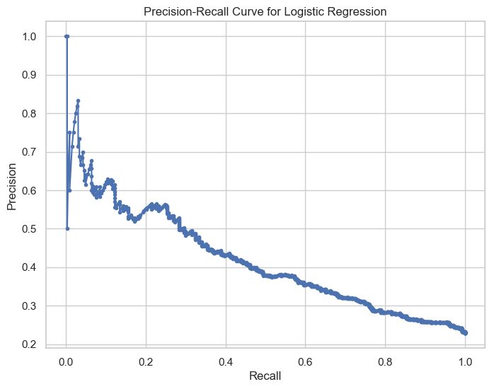

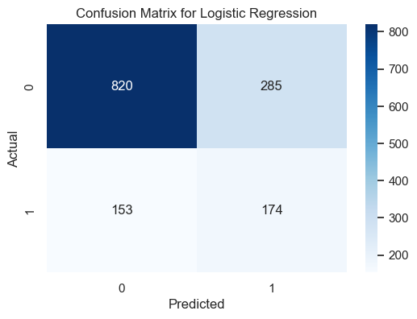

```
====== Random Forest =======
Fitting 5 folds for each of 4 candidates, totalling 20 fits

Best Params for Random Forest: {'classifier__max_depth': 10, 'classifier__n_estimators': 50}

Classification Report for Random Forest:
              precision    recall  f1-score   support

           0       0.82      0.79      0.80      1105
           1       0.37      0.43      0.40       327

    accuracy                           0.71      1432
   macro avg       0.60      0.61      0.60      1432
weighted avg       0.72      0.71      0.71      1432

ROC-AUC for Random Forest: 0.6741
```

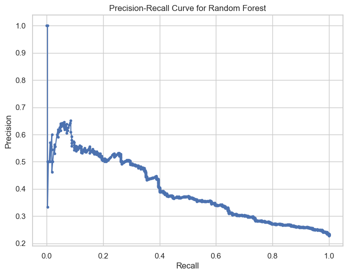

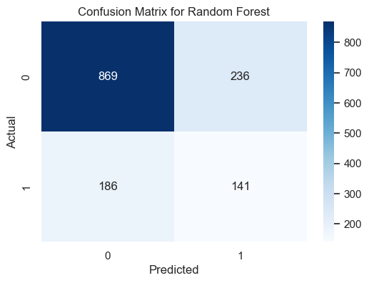

```
====== XGBoost =======
Fitting 5 folds for each of 12 candidates, totalling 60 fits

Best Params for XGBoost: {'classifier__learning_rate': 0.01, 'classifier__max_depth': 3, 'classifier__n_estimators': 200}

Classification Report for XGBoost:
              precision    recall  f1-score   support

           0       0.84      0.72      0.78      1105
           1       0.37      0.55      0.44       327

    accuracy                           0.68      1432
   macro avg       0.61      0.63      0.61      1432
weighted avg       0.74      0.68      0.70      1432

ROC-AUC for XGBoost: 0.6865
```

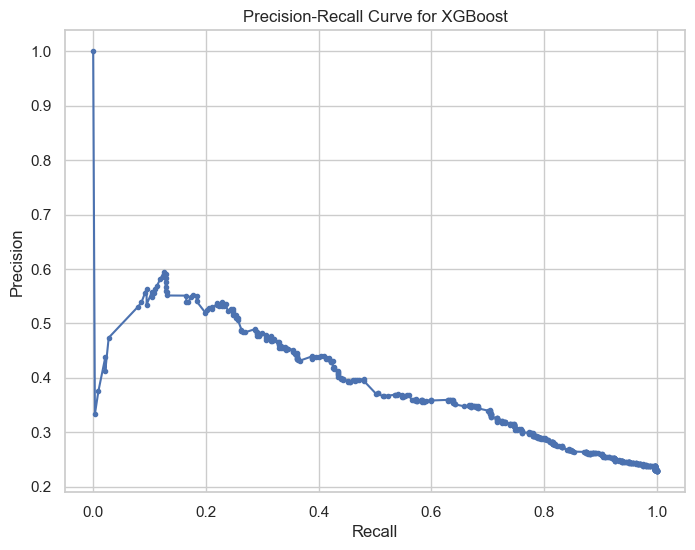

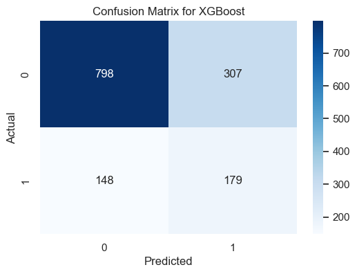

```python
models = {
    'Logistic Regression': LogisticRegression(random_state=42),
    'Random Forest': RandomForestClassifier(random_state=42),
    'XGBoost': XGBClassifier(random_state=42, eval_metric='logloss')
}

best_models = {}
roc_scores = {}
y_preds = {}

for name, model in models.items():
    print(f"\n====== {name} =======")
    best_models[name], roc_scores[name], y_preds[name] = train_evaluate(
        model, name, X_train, y_train, X_test, y_test, preprocessor
    )
```

## Model Comparison Table

```python
comparison = []

for name in models.keys():
    f1 = classification_report(
        y_test,
        y_preds[name],
        output_dict=True
    )['1']['f1-score']

    acc = (y_preds[name] == y_test).mean()

    comparison.append({
        'Model': name,
        'F1-Score': round(f1, 4),
        'Accuracy': round(acc, 4),
        'ROC-AUC': round(roc_scores[name], 4) if roc_scores[name] else None
    })

comparison_df = pd.DataFrame(comparison).sort_values(
    by='F1-Score',
    ascending=False
)

print("\nModel Comparison:")
print(comparison_df)
```

```
Model Comparison:
                 Model  F1-Score  Accuracy  ROC-AUC
0  Logistic Regression    0.4427    0.6941   0.6896
2              XGBoost    0.4403    0.6823   0.6865
1        Random Forest    0.4006    0.7053   0.6741
```

### Model Performance Comparison

[output not shown]

## Feature Importance Plot (Random Forest & XGBoost)

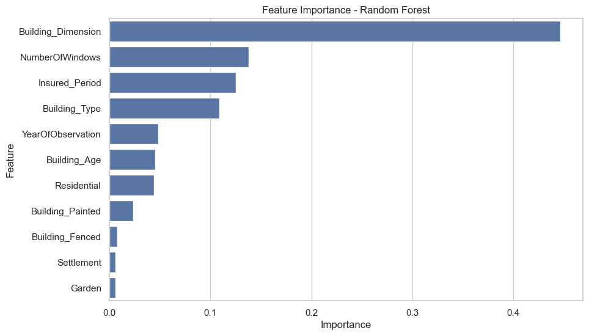

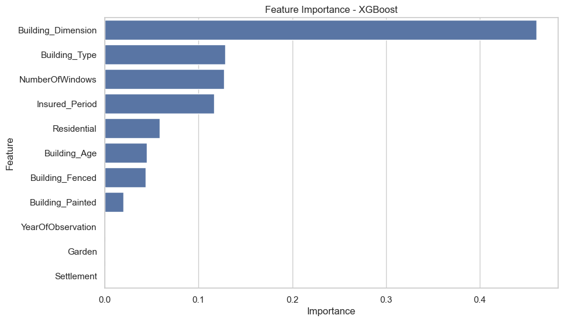

```python
for name in ['Random Forest', 'XGBoost']:
    model = best_models[name]

    if hasattr(model.named_steps['classifier'], 'feature_importances_'):
        importances = model.named_steps['classifier'].feature_importances_
        feature_names = num_cols + cat_cols

        fi_df = pd.DataFrame({
            'Feature': feature_names,
            'Importance': importances
        }).sort_values('Importance', ascending=False)

        plt.figure(figsize=(10, 6))
        sns.barplot(x='Importance', y='Feature', data=fi_df)
        plt.title(f'Feature Importance - {name}')
        plt.show()
```